# 6.3 Developing Confidence Intervals

- A **point estimate** is a single-value estimate of a population parameter.
- We say that a statistic is an **unbiased estimator** if the mean of its distribution is equal to the population parameter.
  - Otherwise, it is a **biased estimator**.
- Ideally, we want estimates that are unbiased with small standard error.
  - For example, a sample mean (unbiased) with a large sample size (results in smaller standard error).

Point estimates are useful, but they only give us so much information. The variability of an estimate is also important!

Take a look at these two boxplots:

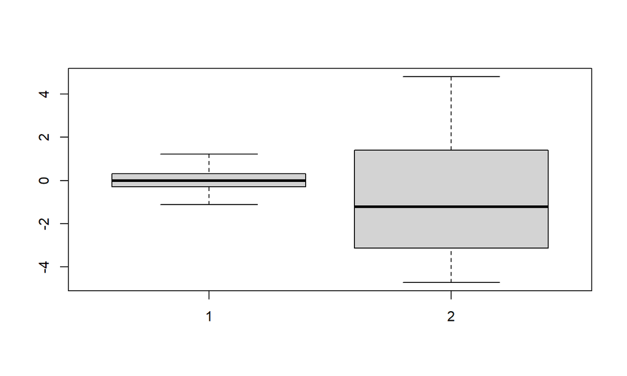

[figure not shown]

## Confidence Intervals

A **confidence interval** is an interval of numbers based on the point estimate of the parameter (along with some other stuff).

- Say we want to be 95% confident about a statement.
- In Statistics, this means that we have arrived at our statement using a method that will give us a correct statement 95% of the time.
- Our best point estimate for \(\mu\) (based on a random sample) is \(\bar{x}\), so that value will make up the center of the interval.
- To create an interval around \(\bar{x}\), we will construct what is called the **margin of error**.
  - We will use the variability of the data along with some normal distribution properties.
  - This will look like \[z\times\frac{\sigma}{\sqrt{n}}\]
  - The value \(z\) will come from the normal distribution and will be based on how confident we want to be, e.g., 95% confident.

Putting everything together, the 95% confidence interval is \[\left(\bar{x} - z_*\frac{\sigma}{\sqrt{n}}, \bar{x} + z_*\frac{\sigma}{\sqrt{n}}\right)\] where \(z_* = 1.96\).

The value \(1.96\) is chosen because \((-1.96 < Z < 1.96) = 0.95\) (this is what makes it a 95% confidence interval!).

## Interpreting a Confidence Interval

If an experiment is run infinitely many times, the true value of \(\mu\) will be contained in 95% of the intervals.

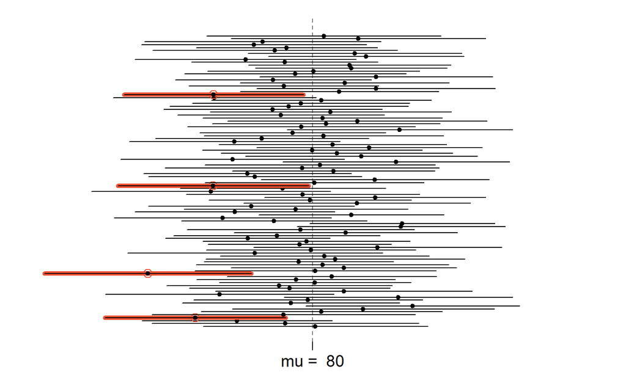

## Example

The preferred keyboard height for typists is approximately normally distributed with \(\sigma=2.0\). A sample of size \(n=31\), resulted in a mean preferred keyboard height of \(80 cm\). Find and interpret a 95% confidence interval for keyboard height.

## Common mistakes

- It is NOT accurate to say that “the probability that \(\mu\) is in the confidence interval is 0.95”.
  - The parameter \(\mu\) is some fixed quantity and it’s either in the interval or it isn’t.
- We are NOT “95% confident that \(\bar{x}\) is in the interval”.
  - The value \(\bar{x}\) is some known quantity and it’s always in the interval.

## Checkpoint

Suppose I took a random sample of 50 Sac State students and asked about their SAT scores and found a mean score of 1112. Prior experience with SAT scores in the CSU system suggests that SAT scores are well-approximated by a normal distribution with standard deviation known to be 50.

1. Find a 95% confidence interval for Sac State SAT scores.
2. Interpret your interval in the context of the problem.
3. What is the width of your interval? If you want a narrower interval, what could you do?